# Analysis of Ercot Historical Load Data

Daniel Pontoh

3/2/2017

# Visualizing the Data

## Required Packages

```r
library(knitr)
library(rvest)
library(readxl)
library(stringr)
library(hrbrthemes)
library(tidyverse)
library(lubridate)
```

## Scraping the Web for Data

```r
pg <- read_html("http://www.ercot.com/gridinfo/load/load_hist")

html_nodes(pg, "a") %>%
  html_attr("href") %>%
  grep(".xls", ., value = TRUE) %>%
  grep("97", ., value = TRUE, invert = TRUE) %>%
  sprintf("http://www.ercot.com%s", .) -> urls

fils <- basename(urls)


for(i in seq_along(urls)) {
  print(i)
  download.file(urls[i], fils[i], method = "wininet", mode = "wb")
}
```

```
## [1] 1
## [1] 2
## [1] 3
## [1] 4
## [1] 5
## [1] 6
## [1] 7
## [1] 8
## [1] 9
## [1] 10
## [1] 11
## [1] 12
## [1] 13
## [1] 14
```

```r
list.files(pattern="ERCO") %>%
  map_df(read_excel) -> ercot_df
```

[output not shown]

[output cut: 18 more lines]

```r
ercot_df
```

```
## # A tibble: 113,952 × 10
##               Hour_End    COAST     EAST FAR_WEST     NORTH  NORTH_C
##                 <dttm>    <dbl>    <dbl>    <dbl>     <dbl>    <dbl>
## 1  2002-01-01 01:00:00 8331.469 1111.097 1094.045  995.2984 10336.30
## 2  2002-01-01 01:59:59 8107.805 1091.482 1083.518  981.1955 10178.05
## 3  2002-01-01 03:00:00 7890.722 1080.258 1085.039  971.3053 10100.89
## 4  2002-01-01 04:00:00 7799.818 1079.726 1093.382  971.2630 10081.57
## 5  2002-01-01 04:59:59 7815.968 1087.935 1106.651  982.5356 10192.22
## 6  2002-01-01 06:00:00 7978.539 1101.932 1133.686  998.8401 10402.11
## 7  2002-01-01 07:00:00 8133.221 1136.170 1169.700 1028.5390 10655.38
## 8  2002-01-01 07:59:59 8136.471 1169.028 1219.351 1057.0542 10881.09
## 9  2002-01-01 09:00:00 8088.579 1206.360 1226.695 1071.6646 11287.13
## 10 2002-01-01 10:00:00 8254.433 1254.367 1248.631 1104.5569 11721.67
## # ... with 113,942 more rows, and 4 more variables: SOUTHERN <dbl>,
## #   SOUTH_C <dbl>, WEST <dbl>, ERCOT <dbl>
```

## Plotting the Data

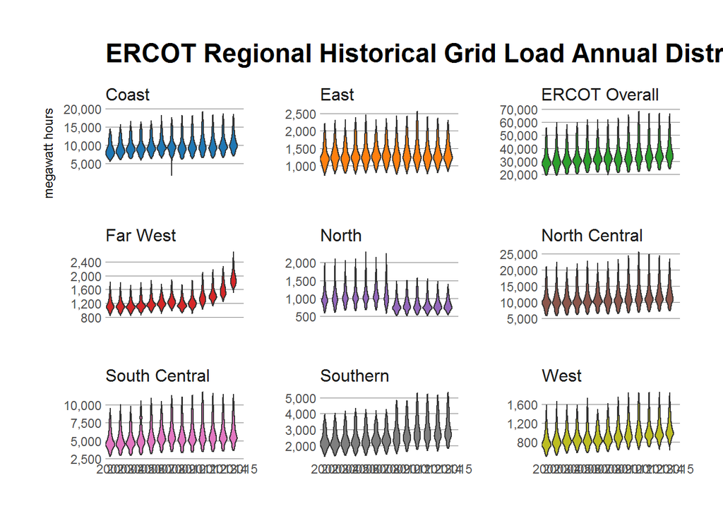

```r
gather(ercot_df, region, mwh, -Hour_End) %>%
  rename(ts=Hour_End) %>%
  mutate(region=str_to_title(region),
         region=ifelse(region == "Ercot", "ERCOT Overall", region),
         region=str_replace(region, "_c", " Central"),
         region=str_replace(region, "_west", " West"),
         day=as.Date(ts),
         year=as.character(lubridate::year(day))) %>%
  ggplot(aes(x=year, y=mwh, group=year)) +
  geom_violin(aes(fill=region)) +
  scale_x_discrete(expand=c(0,0)) +
  scale_y_continuous(label=scales::comma) +
  ggthemes::scale_fill_tableau(palette="tableau10") +
  facet_wrap(~region, scales="free_y") +
  labs(x=NULL, y="megawatt hours",
       title="ERCOT Regional Historical Grid Load Annual Distribution") +
  theme_ipsum_rc(grid="Y") +
  theme(legend.position="none")
```

# Analysis

## What might have cause the uptick in the Far West starting around 2009/2010 and up until now.

I believe that it’s these factors: - increase in fracking equipment being plugged into the grid. - increase in population in West Texas region.

From some browsing on the web, it seems that the uptick in load can be the result of a few different factors, all seemingly closely related.

The first thing I found was that the cities of Odessa and Midland in West Texas were among the fastest growing cities in the nation. These two cities among many others in West Texas fell on the Permian Basin which had become a major target by energy companies for hydraulic fracturing (fracking). As more fracking sites sprung up in West Texas, more fracking equipment was being plugged into the grid. This has been reported to have had a major impact on energy demand and transmission in West Texas. Related to the increase in fracking sites, city population’s began to grow rapidly. One article reports that 97% of apartments in towns and cities on the Permian Basin had become occupied which means more energy demands from those cities from businesses, services, home appliances, construction and more.

1. http://urbanland.uli.org/infrastructure-transit/economics-underlying-book-texas/
   - ctrl + f “Odessa”
2. https://www.texastribune.org/2014/08/25/west-texas-energy-bills-show-booms-unexpected-cost/
   - see “Sucking up energy” section

## Most frequent month for Min, Mean or Median and Max usage per region

### Min

```r
gathered_df <- gather(ercot_df, region, mwh, -Hour_End)

mutate(gathered_df, year = year(Hour_End), month = month(Hour_End)) %>%
  group_by(region, year) %>%
  filter(mwh == min(mwh)) %>%
  ungroup() %>%
  group_by(region) %>%
  count(month) %>%
  filter(n == max(n)) %>%
  kable()
```

| region | month | n |
| --- | --- | --- |
| COAST | 2 | 3 |
| COAST | 10 | 3 |
| EAST | 4 | 4 |
| ERCOT | 4 | 7 |
| FAR_WEST | 4 | 6 |
| NORTH | 4 | 7 |
| NORTH_C | 4 | 6 |
| SOUTH_C | 3 | 6 |
| SOUTHERN | 1 | 3 |
| SOUTHERN | 3 | 3 |
| SOUTHERN | 4 | 3 |
| WEST | 4 | 4 |

### Max

```r
mutate(gathered_df, year = year(Hour_End), month = month(Hour_End)) %>%
  group_by(region, year) %>%
  filter(mwh == max(mwh)) %>%
  ungroup() %>%
  group_by(region) %>%
  count(month) %>%
  filter(n == max(n)) %>%
  kable()
```

| region | month | n |
| --- | --- | --- |
| COAST | 8 | 10 |
| EAST | 8 | 12 |
| ERCOT | 8 | 11 |
| FAR_WEST | 8 | 7 |
| NORTH | 8 | 9 |
| NORTH_C | 8 | 11 |
| SOUTH_C | 8 | 9 |
| SOUTHERN | 8 | 9 |
| WEST | 8 | 11 |

### Mean

```r
mutate(gathered_df, year = year(Hour_End), month = month(Hour_End)) %>%
  group_by(region, year, month) %>%
  summarise(avg = mean(mwh)) %>%
  ungroup() %>%
  group_by(region, year) %>%
  mutate(dif = avg - mean(avg)) %>%
  filter(dif == min(dif)) %>%
  ungroup() %>%
  group_by(region) %>%
  count(month) %>%
  filter(n == max(n)) %>%
  kable()
```

| region | month | n |
| --- | --- | --- |
| COAST | 2 | 5 |
| COAST | 3 | 5 |
| EAST | 3 | 7 |
| ERCOT | 3 | 8 |
| FAR_WEST | 3 | 9 |
| NORTH | 4 | 6 |
| NORTH_C | 3 | 7 |
| SOUTH_C | 3 | 8 |
| SOUTHERN | 3 | 6 |
| WEST | 3 | 7 |

### Median

```r
mutate(gathered_df, year = year(Hour_End), month = month(Hour_End)) %>%
  group_by(region, year, month) %>%
  summarise(med = median(mwh)) %>%
  ungroup() %>%
  group_by(region, year) %>%
  mutate(dif = med - median(med)) %>%
  filter(dif == min(dif)) %>%
  ungroup() %>%
  group_by(region) %>%
  count(month) %>%
  filter(n == max(n)) %>%
  kable()
```

| region | month | n |
| --- | --- | --- |
| COAST | 11 | 5 |
| EAST | 3 | 7 |
| ERCOT | 11 | 6 |
| FAR_WEST | 3 | 6 |
| NORTH | 4 | 7 |
| NORTH_C | 3 | 6 |
| SOUTH_C | 3 | 8 |
| SOUTHERN | 3 | 5 |
| WEST | 3 | 7 |